# Distance, Adjacency, and Weights

Jonathan Kadish

2/4/2021

### Today

- Distance, Adjacency, Weights

### Tonight

- Problem Set 1 and peer feedback template, due before class on Tuesday.
- Problem Set 2 sent out by midnight.

### Next Week

- Spatial Autocorrelation (finish GIA Ch.2, read GIA Ch.7)

# Distance

In small study regions, we can use *Euclidean Distance<>, which can be calculated using Pythagoras’s formula:*

$d_{ij} = \sqrt{(x_i - x_j)^2 + (y_i - y_j)^2}$

Let’s set up some data, using x-y coordinates for each point:

```r
A <- c(40, 43)
B <- c(1, 101)
C <- c(54, 111)
D <- c(104, 65)
E <- c(60, 22)
F <- c(20, 2)
pts <- rbind(A,B,C,D,E,F)
pts
```

```
##   [,1] [,2]
## A   40   43
## B    1  101
## C   54  111
## D  104   65
## E   60   22
## F   20    2
```

Plot the points and labels:

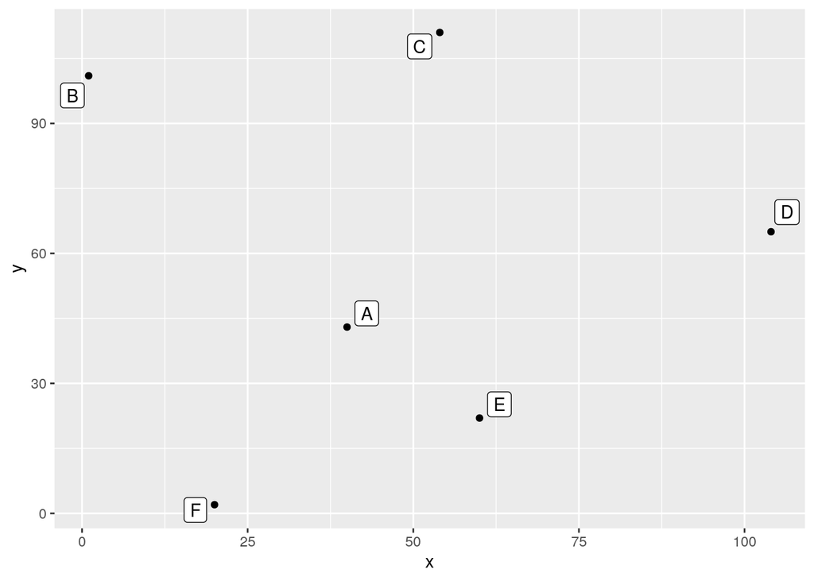

```r
# plot(pts, xlim=c(0,120), ylim=c(0,120), pch=20, cex=2, col='red', xlab='X', ylab='Y', las=1)
# text(pts+5, LETTERS[1:6])

pts.df <- as.data.frame(pts)
names(pts.df) <- c("x", "y")

ggplot(data = pts.df) +
  aes(x, y) +
  geom_point() +
  geom_label_repel(label = rownames(pts.df))
```

What’s the distance between A and B?

```r
A
```

```
## [1] 40 43
```

```r
B
```

```
## [1]   1 101
```

```r
# distance function
euc_distance <- function (c1, c2) {
  sqrt(mean((c2- c1) ^ 2))
}

#test it
euc_distance(A, B)
```

[output not shown]

```r
#works on larger dimensions
euc_distance(c(3,1,8), c(7,9,2))
```

```
## [1] 6.218253
```

For our purposes, it will be useful to calculated a distance matrix. That is, a matrix that classifies the distance from every point to every other point.

Let $\overrightarrow{c} = {c_1, c_2, ..., c_n}$.

Let $d_{ij}$ be the distance between points $i$ and $j$. Then

$$D = \begin{bmatrix}
d_{11} & d_{12} & \dots & d_{1n}\\
d_{21} & d_{22} & \dots & d_{1n}\\
\vdots & \vdots & \ddots & \\
d_{n1} & d_{n2} & &da_{nn}
\end{bmatrix}$$

How would we write a function for this?

Or, we can use the built in function:

```r
#?dist
d <- dist(pts)
d
```

```
##           A         B         C         D         E
## B  69.89278
## C  69.42622  53.93515
## D  67.67570 109.11004  67.94115
## E  29.00000  98.60020  89.20202  61.52235
## F  45.61798 100.80675 114.17968 105.00000  44.72136
```

Why does it look like this?

```r
D = as.matrix(d)
D
```

```
##          A         B         C         D        E         F
## A  0.00000  69.89278  69.42622  67.67570 29.00000  45.61798
## B 69.89278   0.00000  53.93515 109.11004 98.60020 100.80675
## C 69.42622  53.93515   0.00000  67.94115 89.20202 114.17968
## D 67.67570 109.11004  67.94115   0.00000 61.52235 105.00000
## E 29.00000  98.60020  89.20202  61.52235  0.00000  44.72136
## F 45.61798 100.80675 114.17968 105.00000 44.72136   0.00000
```

# Spatial influence

-Much of spatial analysis seeks to answer the question, or control for, how much one point “influences” another. -To model this, we need to think about the relationship between points, and there are some common methods.

## Adjacency

### Distance Adjacency Matrix

To make a distance adjacenty matrix, we set a threshold. Say we want to find other points that are within a distance of 50 from each other.

```r
a <-  D < 50
a
```

```
##       A     B     C     D     E     F
## A  TRUE FALSE FALSE FALSE  TRUE  TRUE
## B FALSE  TRUE FALSE FALSE FALSE FALSE
## C FALSE FALSE  TRUE FALSE FALSE FALSE
## D FALSE FALSE FALSE  TRUE FALSE FALSE
## E  TRUE FALSE FALSE FALSE  TRUE  TRUE
## F  TRUE FALSE FALSE FALSE  TRUE  TRUE
```

It can be useful to have this matrix in terms of ones and zeros, with value `NA` along the diagonal.

```r
diag(a) <- NA
adj50 <- a * 1
adj50
```

```
##    A  B  C  D  E  F
## A NA  0  0  0  1  1
## B  0 NA  0  0  0  0
## C  0  0 NA  0  0  0
## D  0  0  0 NA  0  0
## E  1  0  0  0 NA  1
## F  1  0  0  0  1 NA
```

### Nearest Neighbors Adjacency Matrix

Suppose we want to find the two nearest neighbors adjacency matrix.

```r
cols <- apply(D, 1, order)
D
```

```
##          A         B         C         D        E         F
## A  0.00000  69.89278  69.42622  67.67570 29.00000  45.61798
## B 69.89278   0.00000  53.93515 109.11004 98.60020 100.80675
## C 69.42622  53.93515   0.00000  67.94115 89.20202 114.17968
## D 67.67570 109.11004  67.94115   0.00000 61.52235 105.00000
## E 29.00000  98.60020  89.20202  61.52235  0.00000  44.72136
## F 45.61798 100.80675 114.17968 105.00000 44.72136   0.00000
```

```r
cols
```

```
##      A B C D E F
## [1,] 1 2 3 4 5 6
## [2,] 5 3 2 5 1 5
## [3,] 6 1 4 1 6 1
## [4,] 4 5 1 3 4 2
## [5,] 3 6 5 6 3 4
## [6,] 2 4 6 2 2 3
```

```r
# we need to transpose the result
cols <- t(cols)
```

And then get columns 2 and 3 (why not column 1?)

```r
cols <- cols[, 2:3]
cols
```

```
##   [,1] [,2]
## A    5    6
## B    3    1
## C    2    4
## D    5    1
## E    1    6
## F    5    1
```

As we now have the column numbers, we can make the row-column pairs that we want (`rowcols`).

```r
rowcols <- cbind(rep(1:6, each=2), as.vector(t(cols)))
rowcols
```

```
##       [,1] [,2]
##  [1,]    1    5
##  [2,]    1    6
##  [3,]    2    3
##  [4,]    2    1
##  [5,]    3    2
##  [6,]    3    4
##  [7,]    4    5
##  [8,]    4    1
##  [9,]    5    1
## [10,]    5    6
## [11,]    6    5
## [12,]    6    1
```

We use these pairs as indices to change the values in matrix `Ak3`.

```r
Ak2 <- adj50 * 0
Ak2[rowcols] <- 1
Ak2
```

```
##    A  B  C  D  E  F
## A NA  0  0  0  1  1
## B  1 NA  1  0  0  0
## C  0  1 NA  1  0  0
## D  1  0  0 NA  1  0
## E  1  0  0  0 NA  1
## F  1  0  0  0  1 NA
```

Is it symmetrical? Why (not)?

What is Ak2 * Ak2?

```r
Ak2.0 <- Ak2
diag(Ak2.0) <- 0

Ak2.0 %*% Ak2.0
```

```
##   A B C D E F
## A 2 0 0 0 1 1
## B 0 1 0 1 1 1
## C 2 0 1 0 1 0
## D 1 0 0 0 1 2
## E 1 0 0 0 2 1
## F 1 0 0 0 1 2
```

Seems like someone should have made this into a function…

```r
p_load(spdep)

# make our points a spacial object
pts.sp <- SpatialPoints(pts)

Ak2.sp <- knearneigh(pts.sp, k = 2)
Ak2.sp
```

```
## $nn
##      [,1] [,2]
## [1,]    5    6
## [2,]    3    1
## [3,]    2    4
## [4,]    5    1
## [5,]    1    6
## [6,]    5    1
##
## $np
## [1] 6
##
## $k
## [1] 2
##
## $dimension
## [1] 2
##
## $x
##   coords.x1 coords.x2
## A        40        43
## B         1       101
## C        54       111
## D       104        65
## E        60        22
## F        20         2
##
## attr(,"class")
## [1] "knn"
## attr(,"call")
## knearneigh(x = pts.sp, k = 2)
```

```r
class(Ak2.sp)
```

```
## [1] "knn"
```

```r
Ak2.nb <- knn2nb(Ak2.sp)
Ak2.nb
```

```
## Neighbour list object:
## Number of regions: 6
## Number of nonzero links: 12
## Percentage nonzero weights: 33.33333
## Average number of links: 2
## Non-symmetric neighbours list
```

```r
Ak2.m <- nb2mat(Ak2.nb)
Ak2.m
```

```
##   [,1] [,2] [,3] [,4] [,5] [,6]
## 1  0.0  0.0  0.0  0.0  0.5  0.5
## 2  0.5  0.0  0.5  0.0  0.0  0.0
## 3  0.0  0.5  0.0  0.5  0.0  0.0
## 4  0.5  0.0  0.0  0.0  0.5  0.0
## 5  0.5  0.0  0.0  0.0  0.0  0.5
## 6  0.5  0.0  0.0  0.0  0.5  0.0
## attr(,"call")
## nb2mat(neighbours = Ak2.nb)
```

```r
Ak2.m %*% Ak2.m
```

```
##   [,1] [,2] [,3] [,4] [,5] [,6]
## 1 0.50 0.00 0.00 0.00 0.25 0.25
## 2 0.00 0.25 0.00 0.25 0.25 0.25
## 3 0.50 0.00 0.25 0.00 0.25 0.00
## 4 0.25 0.00 0.00 0.00 0.25 0.50
## 5 0.25 0.00 0.00 0.00 0.50 0.25
## 6 0.25 0.00 0.00 0.00 0.25 0.50
```

#### Weights matrix

Getting the weights matrix is simple.

```r
W <- 1 / D
round(W, 4)
```

```
##        A      B      C      D      E      F
## A    Inf 0.0143 0.0144 0.0148 0.0345 0.0219
## B 0.0143    Inf 0.0185 0.0092 0.0101 0.0099
## C 0.0144 0.0185    Inf 0.0147 0.0112 0.0088
## D 0.0148 0.0092 0.0147    Inf 0.0163 0.0095
## E 0.0345 0.0101 0.0112 0.0163    Inf 0.0224
## F 0.0219 0.0099 0.0088 0.0095 0.0224    Inf
```

Row-normalization is not that difficult either. First get rid if the `Inf` values by changing them to `NA`. (Where did the `Inf` values come from?)

```r
W[!is.finite(W)] <- NA
```

Then compute the row sums.

```r
rtot <- rowSums(W, na.rm=TRUE)
# this is equivalent to
# rtot <- apply(W, 1, sum, na.rm=TRUE)
rtot
```

```
##          A          B          C          D          E          F
## 0.09989170 0.06207541 0.06763182 0.06443810 0.09445017 0.07248377
```

Divide the rows by their totals and check if they row sums add up to 1.

```r
W <- W / rtot
rowSums(W, na.rm=TRUE)
```

```
## A B C D E F
## 1 1 1 1 1 1
```

The values in the columns do not add up to 1.

```r
colSums(W, na.rm=TRUE)
```

```
##         A         B         C         D         E         F
## 1.3402904 0.8038417 0.9108116 0.8166821 1.2350790 0.8932953
```